# Python 1

The following data was scraped from fortune.com. I wanted to know what companies made the most profit in 2018, so I visualized it using the “Seaborn” package in Python. Then, I looked at the Revenue to see if the top companies for profit also had the top revenue.

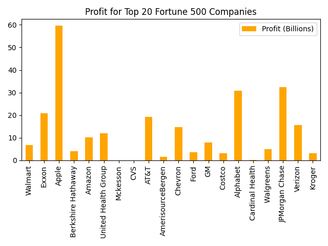

Walmart had the most revenue out of any company but was 11th in profit. This is due to Walmart having much more expenses than other companies like Apple and exxon.

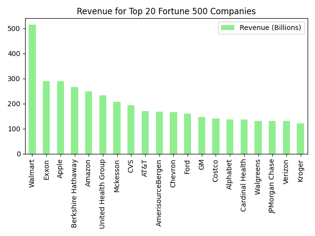

The following graph shows both variables side by side so we can get a better look at the comparison

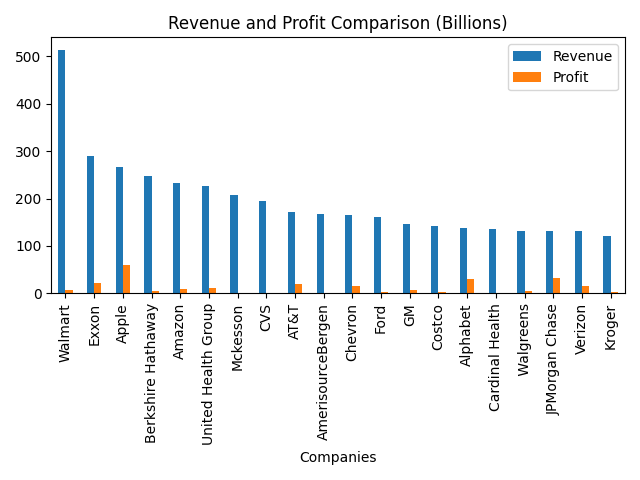

Using a linear regression model, we can see if there is a correlation between the two variables. It would make sense that companies with more revenue would also make more profit generally. The graph shows a slight correlation between the two.

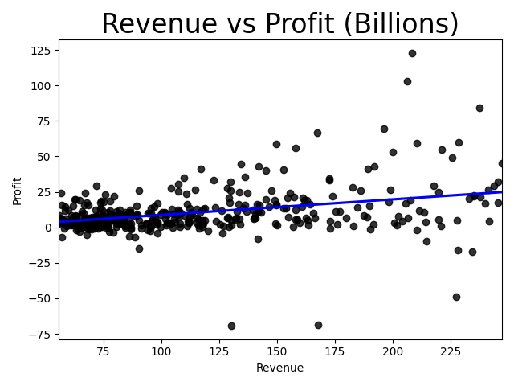